# Item Response Theory Analysis of the Generic Conspiracist Beliefs Scale

Azlina Amir Kassim

## 1. Overview

This report fits graded response models (GRMs) to the 15-item Generic Conspiracist Beliefs Scale (GCBS; Brotherton, French & Pickering, 2013). The scale was built around five related facets of three items each: Government Malfeasance (GM: Q1, Q6, Q11), Malevolent Global Conspiracies (MG: Q2, Q7, Q12), Extraterrestrial Cover-up (ET: Q3, Q8, Q13), Personal Wellbeing (PW: Q4, Q9, Q14) and Control of Information (CI: Q5, Q10, Q15), but it is usually scored as a single total.

This analysis asks the following questions:

1. Can the items be treated as one latent trait, and is there evidence of more than one dimension? (1-, 2- and 3-factor models were compared.)
2. Do items function differently for men and women (DIF)?
3. Which respondents do not fit the model?

## 2. Data

The data come from the Open Source Psychometrics Project ([openpsychometrics.org/_rawdata](https://openpsychometrics.org/_rawdata/), file GCBS.zip). They were collected online in 2016, mostly for personal interest, so this is a convenience sample (n = 2,495 before exclusions).

Each item is scored from 1 (definitely not true) to 5 (definitely true). A score of 0 indicates a missing response.

```r
gcbs <- read.csv("data.csv", header = TRUE, stringsAsFactors = FALSE)

# Keep gender codes 1 (male) and 2 (female) and the 15 items
gcbs <- subset(gcbs, gender == 1 | gender == 2, select = c(Q1:Q15, gender))

# 0 = missing; listwise deletion
gcbs[gcbs == 0] <- NA
gcbs <- na.omit(gcbs)

gcbs$gender2 <- ifelse(gcbs$gender == 2, "F", "M")
nrow(gcbs)
```

```
## [1] 2269
```

```r
table(gcbs$gender2)
```

```
##
##    F    M
## 1086 1183
```

After excluding respondents with missing item responses or a gender code other than 1 or 2, N = 2,269 (1,086 women and 1,183 men).

## 3. Unidimensional graded response model

```r
mod1 <- mirt(gcbs[, 1:15], 1, itemtype = "graded", verbose = FALSE)
```

### Item parameters

`a` is discrimination (how sharply an item separates people at different trait levels). `b1`-`b4` are the trait levels at which a respondent has a 50% chance of answering at or above each successive category.

```r
coef(mod1, IRTpars = TRUE, simplify = TRUE)$items
```

```
##            a          b1          b2           b3         b4
## Q1  2.206881 -1.21715151 -0.66422619 -0.275485094  0.5535783
## Q2  2.397477 -0.85958816 -0.21821510  0.235416578  0.9298032
## Q3  1.920280  0.18391371  0.63915969  1.146012462  1.7379905
## Q4  2.661204 -0.50657644  0.05109021  0.492168163  1.2800556
## Q5  1.912841 -1.13399830 -0.53181874 -0.089181216  0.8590746
## Q6  2.497733 -0.87731062 -0.33290572  0.094007915  0.8109549
## Q7  2.530043 -0.49867201  0.07084630  0.458120488  1.1037668
## Q8  1.800532 -0.15610014  0.25336659  0.749267612  1.2572445
## Q9  2.312696 -0.11829843  0.44110004  0.861861463  1.4802800
## Q10 1.413613 -1.66192763 -0.97360397 -0.372689993  0.7954236
## Q11 2.285276 -1.19710177 -0.59188740  0.001992373  0.8629489
## Q12 3.092506 -0.45064546  0.03541850  0.440228601  1.0546773
## Q13 2.113671  0.07782273  0.53182345  1.100333561  1.6742653
## Q14 2.423223 -0.78506343 -0.20854707  0.248766055  0.9918377
## Q15 1.733579 -2.39817616 -1.80332921 -1.244731254 -0.1570950
```

### Loadings

```r
summary(mod1)
```

```
##        F1    h2
## Q1  0.792 0.627
## Q2  0.815 0.665
## Q3  0.748 0.560
## Q4  0.842 0.710
## Q5  0.747 0.558
## Q6  0.826 0.683
## Q7  0.830 0.688
## Q8  0.727 0.528
## Q9  0.805 0.649
## Q10 0.639 0.408
## Q11 0.802 0.643
## Q12 0.876 0.768
## Q13 0.779 0.607
## Q14 0.818 0.670
## Q15 0.714 0.509
##
## SS loadings:  9.272
## Proportion Var:  0.618
##
## Factor correlations:
##
##    F1
## F1  1
```

### Global fit

```r
M2(mod1)
```

```
##            M2 df p RMSEA RMSEA_5 RMSEA_95 SRMSR   TLI  CFI
## stats 237.409 45 0 0.043   0.038    0.049 0.077 0.961 0.97
```

**Interpretation:** The one-factor model showed good global fit: RMSEA = .043 (90% CI .038–.049), CFI = .97 and TLI = .96. SRMSR = .077 is just under the .08 guideline. The M2 test was significant, M2(45) = 237.4, p < .001, indicating the model does not fit perfectly. With a sample this large the test is very sensitive to small misfit, so the approximate fit indices are the better guide.

### Item fit

```r
itf <- itemfit(mod1)
itf$p.adj <- round(p.adjust(itf$p.S_X2, method = "BH"), 3)
itf
```

```
##    item    S_X2 df.S_X2 RMSEA.S_X2 p.S_X2 p.adj
## 1    Q1 160.303     160      0.001  0.478 0.531
## 2    Q2 178.688     156      0.008  0.103 0.189
## 3    Q3 192.966     167      0.008  0.082 0.183
## 4    Q4 155.210     149      0.004  0.347 0.435
## 5    Q5 169.523     170      0.000  0.496 0.531
## 6    Q6 182.023     156      0.009  0.076 0.183
## 7    Q7 206.730     158      0.012  0.006 0.084
## 8    Q8 194.564     179      0.006  0.202 0.303
## 9    Q9 200.726     159      0.011  0.014 0.084
## 10  Q10 224.420     184      0.010  0.023 0.084
## 11  Q11 196.557     157      0.011  0.018 0.084
## 12  Q12 145.948     140      0.004  0.348 0.435
## 13  Q13 148.306     158      0.000  0.698 0.698
## 14  Q14 178.696     157      0.008  0.113 0.189
## 15  Q15 159.101     136      0.009  0.086 0.183
```

**Interpretation:** S-X² values are interpreted alongside the item RMSEA, because with a sample of this size even trivial misfit is statistically significant.

Four items (Q7, Q9, Q10 and Q11) had unadjusted p-values below .05, but the item-level RMSEA values were all ≤ .012, indicating negligible misfit, and none remained significant after Benjamini-Hochberg correction for 15 comparisons (all adjusted p ≥ .084). No items showed meaningful misfit.

### Category response curves

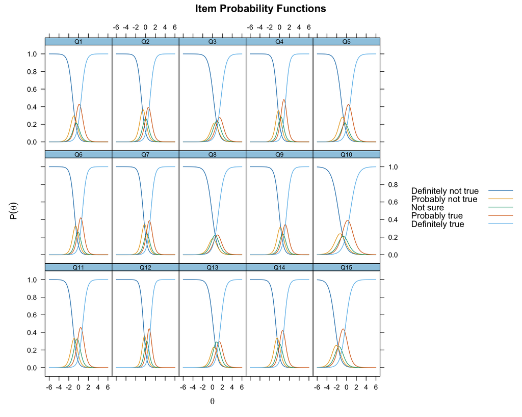

```r
plot(mod1, type = "trace", as.table = TRUE,
     auto.key = list(text = c("Definitely not true", "Probably not true",
                              "Not sure", "Probably true", "Definitely true"),
                     space = "right", points = FALSE, lines = TRUE))
```

**Interpretation:** The category response curves show that the response options are ordered as intended for all 15 items: as belief increases, the most likely answer moves from “definitely not true” to “definitely true” with no reversals, consistent with the increasing thresholds (b1–b4). “Probably true” is the most distinct middle category, whereas “Not sure” has the lowest peak and is rarely the single most likely response, so it contributes less information than the other options. The curves also reflect the item parameters: Q12 has the steepest curves (highest discrimination) and Q10 the flattest (lowest). The ET items (Q3, Q8, Q13) are harder to endorse, with curves located at higher belief levels and overlapping middle categories, whereas Q15 is easy to endorse, with curves located at lower belief levels.

### Item endorsement for an average respondent

The probability of answering 4 or 5 at the sample mean (theta = 0).

```r
endorse <- sapply(1:15, function(i)
  sum(probtrace(extract.item(mod1, i), matrix(0))[4:5]))

endorse_tab <- data.frame(item = paste0("Q", 1:15),
                          p_endorse = round(endorse, 3))
endorse_tab[order(-endorse_tab$p_endorse), ]
```

```
##    item p_endorse
## 15  Q15     0.896
## 1    Q1     0.647
## 10  Q10     0.629
## 5    Q5     0.543
## 11  Q11     0.499
## 6    Q6     0.442
## 2    Q2     0.363
## 14  Q14     0.354
## 7    Q7     0.239
## 4    Q4     0.213
## 8    Q8     0.206
## 12  Q12     0.204
## 9    Q9     0.120
## 3    Q3     0.100
## 13  Q13     0.089
```

## 4. Is the scale unidimensional? Exploratory models

Two- and three-factor exploratory models are compared with the one-factor model.

```r
mod2 <- mirt(gcbs[, 1:15], 2, verbose = FALSE)
mod3 <- mirt(gcbs[, 1:15], 3, verbose = FALSE)

anova(mod1, mod2)
```

```
##           AIC    SABIC       HQ      BIC    logLik       X2 df p
## mod1 83291.72 83482.96 83448.43 83721.25 -41570.86
## mod2 80890.23 81117.17 81076.19 81399.94 -40356.11 2429.488 14 0
```

```r
anova(mod2, mod3)
```

```
##           AIC    SABIC       HQ      BIC    logLik      X2 df p
## mod2 80890.23 81117.17 81076.19 81399.94 -40356.11
## mod3 80092.24 80352.33 80305.36 80676.40 -39944.12 823.992 13 0
```

```r
summary(mod3, rotate = "oblimin")
```

```
##
## Rotation:  oblimin
##
## Rotated factor loadings:
##
##         F1     F2     F3    h2
## Q1   0.837 -0.061  0.048 0.701
## Q2   0.097 -0.031  0.816 0.770
## Q3  -0.045  0.910  0.083 0.871
## Q4   0.450  0.213  0.253 0.685
## Q5   0.636  0.137  0.024 0.566
## Q6   0.659  0.007  0.206 0.702
## Q7  -0.049  0.044  0.913 0.814
## Q8   0.028  0.985 -0.069 0.925
## Q9   0.293  0.297  0.303 0.633
## Q10  0.546  0.118  0.019 0.416
## Q11  0.860 -0.091  0.061 0.727
## Q12  0.035  0.027  0.898 0.891
## Q13  0.059  0.829  0.072 0.841
## Q14  0.766  0.171 -0.091 0.665
## Q15  0.821 -0.001 -0.070 0.586
##
## Rotated SS loadings:  4.143 2.698 2.543
##
## Factor correlations:
##
##       F1    F2 F3
## F1 1.000
## F2 0.652 1.000
## F3 0.803 0.613  1
```

An oblique (oblimin) rotation is used because the facets are expected to correlate. A four-factor model was also attempted. It did not converge reliably (a negative likelihood-ratio statistic against the three-factor model), so it is not reported; with 15 items and three items per facet, the data probably cannot support that much structure.

```r
mod4 <- mirt(gcbs[, 1:15], 4)   # attempted; did not converge reliably, so not run here
```

**Interpretation.** Fit improved significantly from one to two factors (p < .001) and from two to three factors (p < .001). A four-factor model did not converge, so three factors is the upper limit this item set supports. In the three-factor oblimin solution, two factors correspond to complete published facets: ET (Q3, Q8, Q13) and MG (Q2, Q7, Q12). The remaining items (GM, CI, and PW items Q4 and Q14) load mainly on a single broad factor. Q9 (PW) loads weakly and about equally on all three factors, so it doesn’t clearly belong to any of them. The factors were strongly correlated (r = .61 to .80). Although the scale was developed with five facets, each has only three items, which may make them hard to separate in an exploratory analysis. A confirmatory comparison would be needed to test the published structure directly.

## 5. Differential item functioning (gender)

DIF tests whether men and women with the same level of the trait answer an item differently. A one-factor graded model is fitted to both groups with all item parameters constrained equal across groups, and group means and variances free. Each item is then released in turn (its slope and four intercepts are allowed to differ) and compared with the constrained model using a likelihood-ratio test. p-values are adjusted with the Benjamini-Hochberg procedure.

```r
items <- gcbs[, 1:15]

mg <- multipleGroup(items, 1, itemtype = "graded",
                    group = gcbs$gender2,
                    invariance = c(colnames(items), "free_means", "free_var"),
                    SE = TRUE, verbose = FALSE)

dif_results <- DIF(mg,
                   which.par = c("a1", "d1", "d2", "d3", "d4"),
                   scheme = "drop",
                   p.adjust = "BH")
dif_results
```

```
##     groups converged     AIC   SABIC      HQ     BIC     X2 df     p adj_p
## Q1     F,M      TRUE  -7.820   4.930   2.628  20.816  17.82  5 0.003 0.005
## Q2     F,M      TRUE -22.027  -9.277 -11.580   6.609 32.027  5     0 0.000
## Q3     F,M      TRUE -52.656 -39.906 -42.208 -24.020 62.656  5     0 0.000
## Q4     F,M      TRUE -13.004  -0.254  -2.557  15.631 23.004  5     0 0.001
## Q5     F,M      TRUE -11.390   1.359  -0.943  17.245  21.39  5 0.001 0.001
## Q6     F,M      TRUE  -3.582   9.168   6.865  25.054 13.582  5 0.018 0.021
## Q7     F,M      TRUE  -1.106  11.643   9.341  27.529 11.106  5 0.049 0.053
## Q8     F,M      TRUE -32.071 -19.321 -21.623  -3.435 42.071  5     0 0.000
## Q9     F,M      TRUE   5.135  17.885  15.582  33.770  4.865  5 0.433 0.433
## Q10    F,M      TRUE  -6.439   6.311   4.009  22.197 16.439  5 0.006 0.007
## Q11    F,M      TRUE -13.403  -0.654  -2.956  15.232 23.403  5     0 0.001
## Q12    F,M      TRUE -25.509 -12.759 -15.062   3.127 35.509  5     0 0.000
## Q13    F,M      TRUE -13.507  -0.758  -3.060  15.128 23.507  5     0 0.001
## Q14    F,M      TRUE  -8.627   4.122   1.820  20.008 18.627  5 0.002 0.004
## Q15    F,M      TRUE  -7.514   5.236   2.934  21.122 17.514  5 0.004 0.005
```

**Interpretation:** In this first pass, 13 of 15 items were flagged, which can occur when a few items differ and the rest are held equal. A sequential purification step (using BIC) therefore freed the clearest items one at a time and retested the rest.

```r
dif_purified <- DIF(mg,
                    which.par = c("a1", "d1", "d2", "d3", "d4"),
                    scheme = "drop_sequential",
                    seq_stat = "BIC",
                    max_run = 10)
dif_purified
```

```
##    groups converged     AIC   SABIC      HQ     BIC     X2 df p adj_p
## Q3    F,M      TRUE -57.691 -44.941 -47.244 -29.055 67.691  5 0     0
## Q8    F,M      TRUE -37.106 -24.356 -26.659  -8.471 47.106  5 0     0
```

**Interpretation:** Only Q3 and Q8 (both ET items) showed DIF (Q3: X²(5) = 67.7; Q8: X²(5) = 47.1; both adjusted p < .001). Q13, the third ET item, was not flagged. To see the direction and size of the difference, a final model freed only these two items and the group-specific thresholds were compared (below), followed by expected-score plots.

```r
anchors <- colnames(items)[-c(3, 8)]

mg_final <- multipleGroup(items, 1, itemtype = "graded",
                          group = gcbs$gender2,
                          invariance = c(anchors, "free_means", "free_var"),
                          SE = TRUE, verbose = FALSE)

coef(mg_final, IRTpars = TRUE, simplify = TRUE)
```

```
## $F
## $items
##         a     b1     b2     b3     b4
## Q1  2.075 -1.367 -0.778 -0.365  0.517
## Q2  2.264 -0.984 -0.304  0.177  0.915
## Q3  1.756 -0.093  0.425  0.967  1.618
## Q4  2.487 -0.612 -0.018  0.453  1.293
## Q5  1.791 -1.281 -0.639 -0.167  0.843
## Q6  2.353 -1.004 -0.426  0.028  0.790
## Q7  2.385 -0.602  0.003  0.414  1.101
## Q8  1.686 -0.434  0.047  0.570  1.108
## Q9  2.168 -0.198  0.398  0.846  1.505
## Q10 1.331 -1.838 -1.107 -0.468  0.773
## Q11 2.152 -1.345 -0.701 -0.070  0.845
## Q12 2.925 -0.550 -0.035  0.395  1.048
## Q13 1.980  0.011  0.495  1.101  1.713
## Q14 2.271 -0.908 -0.294  0.193  0.984
## Q15 1.632 -2.624 -1.990 -1.396 -0.239
##
## $means
## F1
##  0
##
## $cov
##    F1
## F1  1
##
##
## $M
## $items
##         a     b1     b2     b3     b4
## Q1  2.075 -1.367 -0.778 -0.365  0.517
## Q2  2.264 -0.984 -0.304  0.177  0.915
## Q3  1.900  0.330  0.794  1.344  1.953
## Q4  2.487 -0.612 -0.018  0.453  1.293
## Q5  1.791 -1.281 -0.639 -0.167  0.843
## Q6  2.353 -1.004 -0.426  0.028  0.790
## Q7  2.385 -0.602  0.003  0.414  1.101
## Q8  1.702 -0.057  0.349  0.895  1.451
## Q9  2.168 -0.198  0.398  0.846  1.505
## Q10 1.331 -1.838 -1.107 -0.468  0.773
## Q11 2.152 -1.345 -0.701 -0.070  0.845
## Q12 2.925 -0.550 -0.035  0.395  1.048
## Q13 1.980  0.011  0.495  1.101  1.713
## Q14 2.271 -0.908 -0.294  0.193  0.984
## Q15 1.632 -2.624 -1.990 -1.396 -0.239
##
## $means
##     F1
## -0.138
##
## $cov
##      F1
## F1 1.25
```

**Interpretation:** Men’s thresholds were about 0.3–0.4 SD higher than women’s for both items, with similar discrimination, so women were more likely to endorse them at the same level of overall belief. Separately from DIF, the latent trait was scaled with women as the reference group (mean = 0, variance = 1), and men’s estimated mean was slightly lower (−0.14) with greater variance (1.25).

Plots are created for Q3 and Q8, the only items flagged after purification (all others were constrained equal across groups). They show the response difference on the 1–5 scale at each belief level.

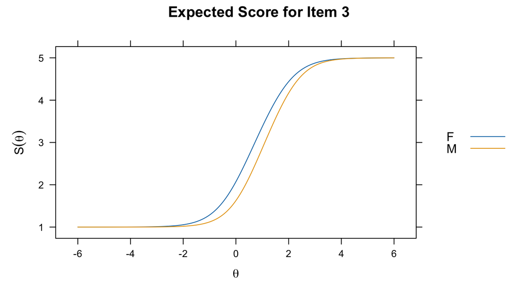

```r
itemplot(mg_final, 3, type = "score")
```

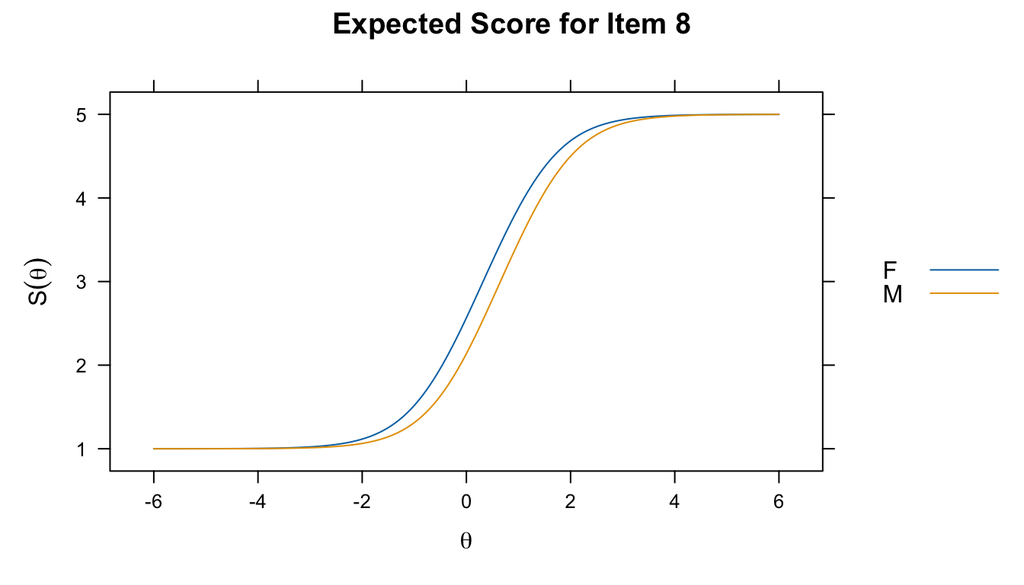

```r
itemplot(mg_final, 8, type = "score")
```

**Interpretation:** Only Q3 and Q8 (both ET items) showed gender DIF after purification. At the same level of overall belief, women were more likely to endorse them, by roughly 0.3–0.5 response points in the middle of the trait range. The DIF is statistically clear but moderate in size, and it affects two of the 15 items.

## 6. Person fit

Person-fit statistics flag respondents whose answers are unusual given the one-factor model.

```r
pf <- personfit(mod1)
flagged <- pf[abs(pf$Zh) > 3, ]
nrow(flagged)
```

```
## [1] 17
```

A cut-off of |Zh| > 3 is used because |Zh| > 2 flags about 5% of any sample by chance. Looking at the raw responses of flagged cases:

```r
ids <- as.numeric(rownames(flagged))
fr <- gcbs[ids, 1:15]
fr$avg_other <- rowMeans(fr[, c("Q1","Q2","Q4","Q5","Q6","Q7","Q9","Q10",
                                "Q11","Q12","Q14","Q15")])
fr$avg_ET <- rowMeans(fr[, c("Q3","Q8","Q13")])
fr[, c("avg_other", "avg_ET")]
```

```
##      avg_other   avg_ET
## 59    2.750000 4.000000
## 205   2.083333 5.000000
## 252   3.750000 2.666667
## 716   1.916667 4.000000
## 802   2.416667 3.333333
## 820   2.750000 3.666667
## 918   1.916667 4.333333
## 1513  2.666667 3.666667
## 1563  3.500000 5.000000
## 1641  3.416667 2.333333
## 2068  3.583333 1.000000
## 2095  1.583333 4.333333
## 2154  1.000000 5.000000
## 2208  2.000000 3.666667
## 2258  3.250000 4.666667
## 2263  3.500000 4.333333
## 2305  2.416667 3.333333
```

**Interpretation: S**ome flagged respondents score low on most items but high on the ET items (for example, respondent 2154 averaged 1.0 on the other items and 5.0 on the ET items). A few show the reverse pattern, scoring higher on most items but low on the ET items (for example, respondent 2068, 3.6 vs 1.0). This is a descriptive observation, not a tested result. These respondents were selected because they misfit a one-factor model, so such patterns are partly expected. Counting how common each pattern is across all respondents, and screening for careless responding, would be needed before drawing conclusions.

## 7. Conclusions

- A single-factor graded response model fits acceptably (see M2 above), which supports scoring the GCBS as one total.
- More than one dimension is also supported. ET and MG separate clearly, consistent with the published facet structure.
- No items showed meaningful misfit: four had unadjusted p < .05 but with negligible effect sizes, and none survived correction for multiple comparisons.
- Only two of 15 items (Q3 and Q8, both ET) showed gender DIF after purification, with women more likely to endorse them at the same level of belief.

## 8. Limitations

- Convenience sample collected online, with no check for careless responding.
- Only male and female respondents are included.
- The four-factor model did not converge, so conclusions about dimensionality stop at three factors. The published five-facet structure was not tested confirmatorily.
- DIF was tested by constraining all items equal and identifying DIF items by sequential purification with BIC. Effect sizes were read from expected-score plots and not computed formally.

## References

Brotherton, R., French, C. C., & Pickering, A. D. (2013). Measuring belief in conspiracy theories: The Generic Conspiracist Beliefs Scale. *Frontiers in Psychology, 4*, 279.

Open Source Psychometrics Project. (2016). *Answers to the Generic Conspiracist Beliefs Scale* [Data set]. https://openpsychometrics.org/_rawdata/